# hw3_attempt

##### 02.09.2025

## Assignment 3

```python
import numpy as np
import pandas as pd
import seaborn as sns
import matplotlib.pyplot as plt
from sklearn.preprocessing import StandardScaler
from sklearn.decomposition import PCA
from sklearn.model_selection import train_test_split
from sklearn.preprocessing import scale
from sklearn.metrics import r2_score
```

```python
data=pd.read_csv('/Users/Devyani/msads/ml1/hw3/AmesHousing.csv')
```

### Part 2

#### 1: Split samples into two random samples of sizes 70% and 30%.

```python
numeric_data = data.select_dtypes(include=[np.number]).dropna()
```

```python
train_data, test_data = train_test_split(numeric_data, test_size=0.3, random_state=42)
```

#### 2: Perform principal components of numeric variables from the Ames Housing Data on the training sample.

##### 1: Standardize your data so that each variable has mean = 0 and variance = 1

```python
scaler = StandardScaler()
```

##### 2: Scale the test set using the mean and standard deviation of the training set. See "Assignment 2 Steps" for the code. This will help prevent information from “leaking” into the test set. Let’s be rigorous :)

```python
train_scaled = scaler.fit_transform(train_data)
test_scaled = scaler.transform(test_data)
```

##### 3: Perform PCA on the train data. Use PCA (Python) function or princomp (R) function.

```python
pca = PCA()
train_pca = pca.fit_transform(train_scaled)
```

#### 3: Generate Scree Plots and select number of components you would retain.

##### 1: Display cumulative sum of variance accounted for by each additional PCA factor. Train_PCA.explained_variance_ratio_(Python)

```python
explained_variance_ratio = pca.explained_variance_ratio_
cumulative_variance_ratio = np.cumsum(explained_variance_ratio)
```

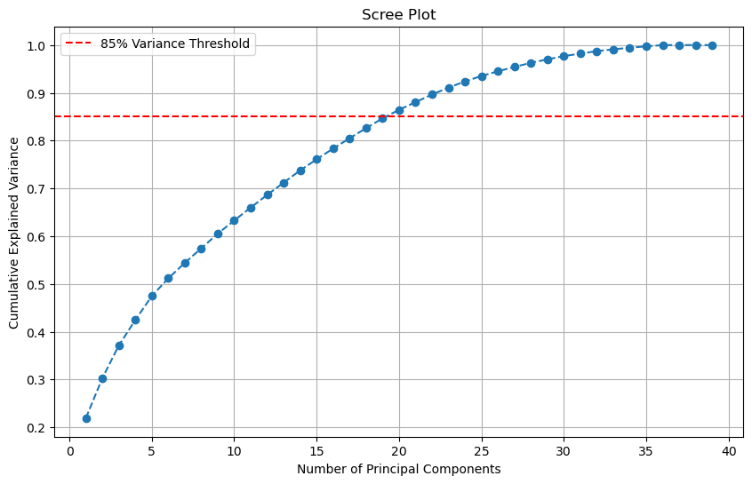

```python
plt.figure(figsize=(10, 6))
plt.plot(range(1, len(cumulative_variance_ratio) + 1), cumulative_variance_ratio, marker='o', linestyle='--')
plt.title('Scree Plot')
plt.xlabel('Number of Principal Components')
plt.ylabel('Cumulative Explained Variance')
plt.axhline(y=0.85, color='r', linestyle='--', label='85% Variance Threshold')
plt.legend()
plt.grid()
plt.show()
```

##### 2: Apply the "elbow rule" to decide how many components you'd like to include.

```python
num_components = np.argmax(cumulative_variance_ratio >= 0.85) + 1
print(f"Number of components to retain (85% variance): {num_components}")
```

```
Number of components to retain (85% variance): 20
```

#### 4: Plot Component 1 loadings (x-axis) versus Component 2 loadings (y-axis). Use this plot to interpret and name the Components. Repeat this by plotting Component (1) separately versus all components you decided to retain from Step 3 (Component 3, Component 4 etc). Can you interpret each of the components you decide to retain? In case a component is not interpretable, note that.

```python
loadings = pd.DataFrame(pca.components_, columns=numeric_data.columns)
```

```python
loadings.head()
```

|  | Order | PID | MS SubClass | Lot Frontage | Lot Area | Overall Qual | Overall Cond | Year Built | Year Remod/Add | Mas Vnr Area | ... | Wood Deck SF | Open Porch SF | Enclosed Porch | 3Ssn Porch | Screen Porch | Pool Area | Misc Val | Mo Sold | Yr Sold | SalePrice |
| --- | --- | --- | --- | --- | --- | --- | --- | --- | --- | --- | --- | --- | --- | --- | --- | --- | --- | --- | --- | --- | --- |
| 0 | -0.019861 | -0.108144 | -0.014119 | 0.151268 | 0.145417 | 0.275065 | -0.116780 | 0.236763 | 0.202207 | 0.196628 | ... | 0.116972 | 0.141467 | -0.087068 | -0.001255 | 0.023856 | 0.032257 | -0.006368 | 0.018236 | -0.005253 | 0.304690 |
| 1 | 0.089523 | 0.093368 | 0.144454 | -0.001603 | 0.008680 | -0.023828 | 0.048224 | -0.164145 | -0.075899 | -0.018797 | ... | -0.040246 | 0.057184 | 0.122259 | -0.039746 | 0.000463 | -0.001447 | -0.003767 | 0.035086 | -0.081021 | -0.019903 |
| 2 | 0.120710 | 0.118453 | -0.275253 | 0.334034 | 0.352009 | -0.115076 | 0.130465 | -0.286170 | -0.240739 | 0.045053 | ... | 0.047102 | -0.013365 | 0.182904 | 0.000947 | 0.127578 | 0.190144 | 0.056169 | 0.012529 | -0.092601 | 0.020830 |
| 3 | -0.483201 | -0.048769 | 0.183415 | -0.052471 | -0.037572 | -0.002832 | 0.103082 | -0.039639 | -0.001379 | 0.051385 | ... | 0.094219 | 0.011591 | 0.014384 | -0.009248 | 0.056453 | 0.026935 | 0.074424 | -0.141774 | 0.485947 | 0.038782 |
| 4 | -0.462265 | -0.027550 | -0.243187 | 0.153196 | 0.038653 | -0.013409 | 0.013637 | -0.086584 | -0.023180 | -0.049376 | ... | -0.126685 | -0.044398 | 0.087618 | 0.059988 | -0.030979 | -0.044096 | 0.029426 | -0.124978 | 0.464360 | -0.039743 |

5 rows × 39 columns

```python
loadings.columns = [f'PC{i+1}' for i in range(loadings.shape[1])]
```

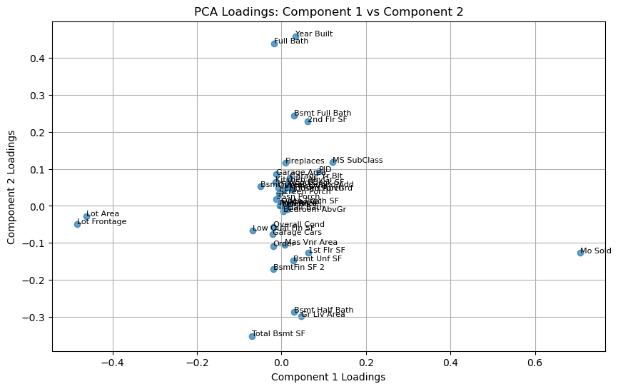

```python
plt.figure(figsize=(10, 6))
plt.scatter(loadings['PC1'], loadings['PC2'], alpha=0.7)
for i, var_name in enumerate(numeric_data.columns):
    plt.annotate(var_name, (loadings.iloc[i, 0], loadings.iloc[i, 1]), fontsize=8)
plt.title('PCA Loadings: Component 1 vs Component 2')
plt.xlabel('Component 1 Loadings')
plt.ylabel('Component 2 Loadings')
plt.grid()
plt.show()
```

We decided to retain all the components except month sold as they appear interpretable, but month sold is an anomaly and should be excluded from further analysis as it is not interpretable.

```python
numeric_data = numeric_data.drop(columns=["Mo Sold"])
```

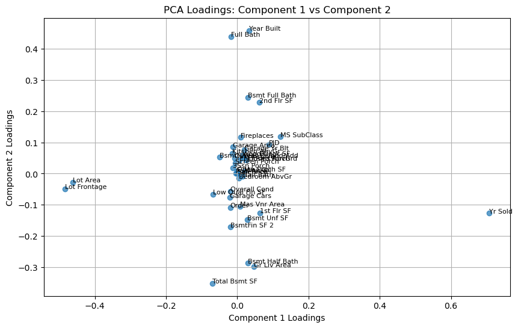

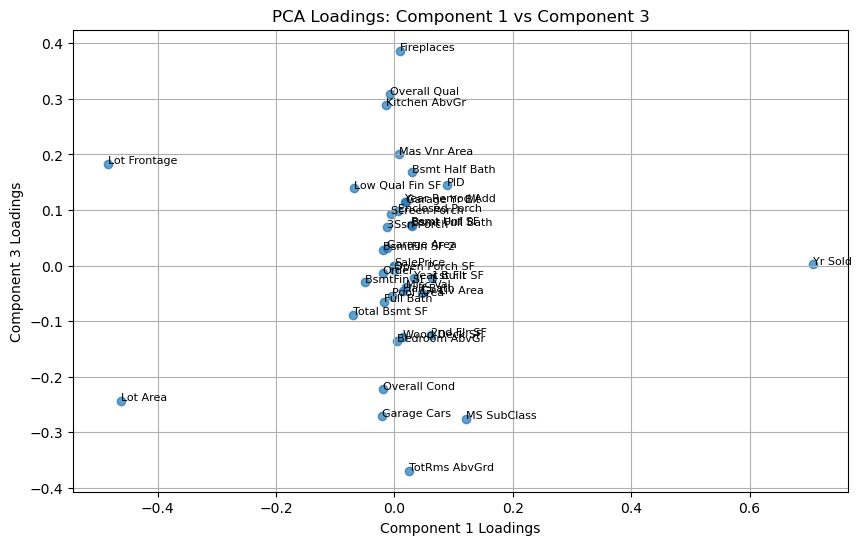

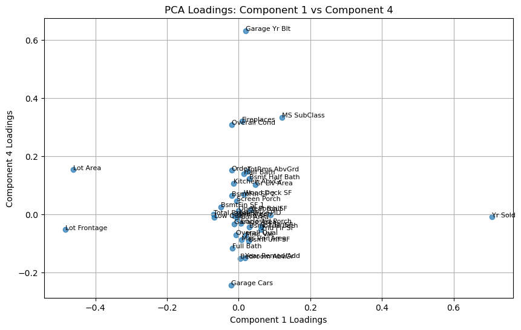

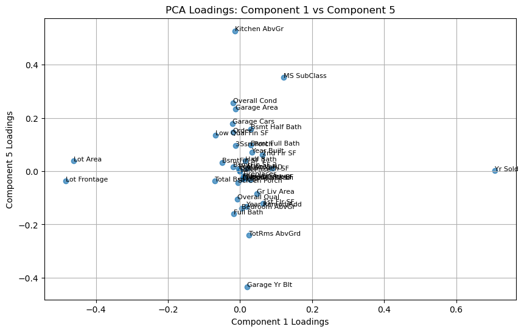

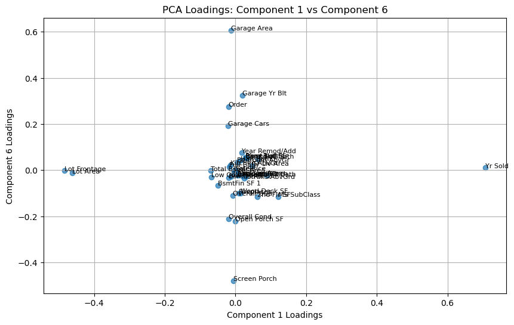

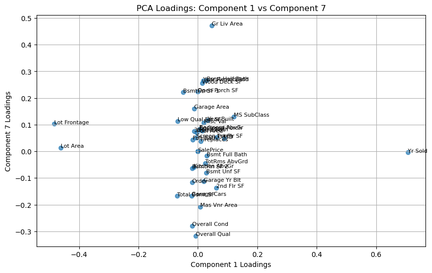

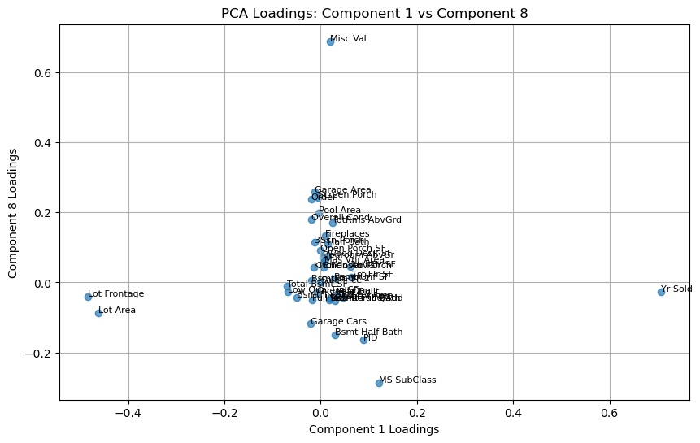

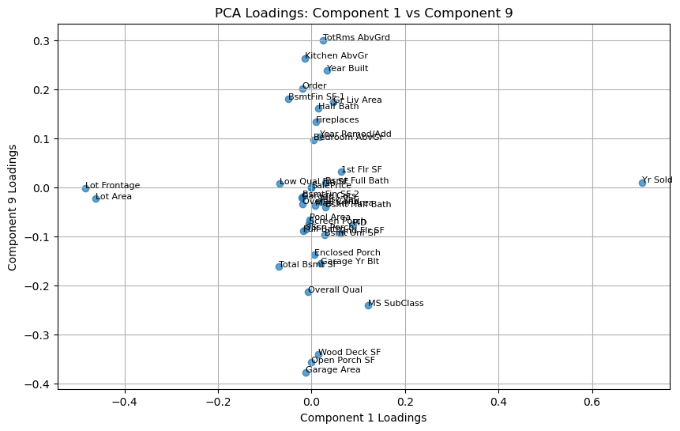

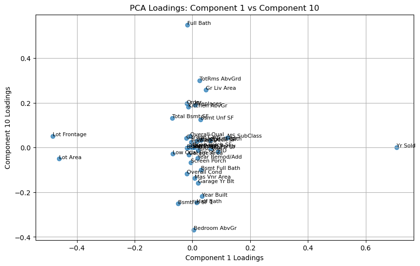

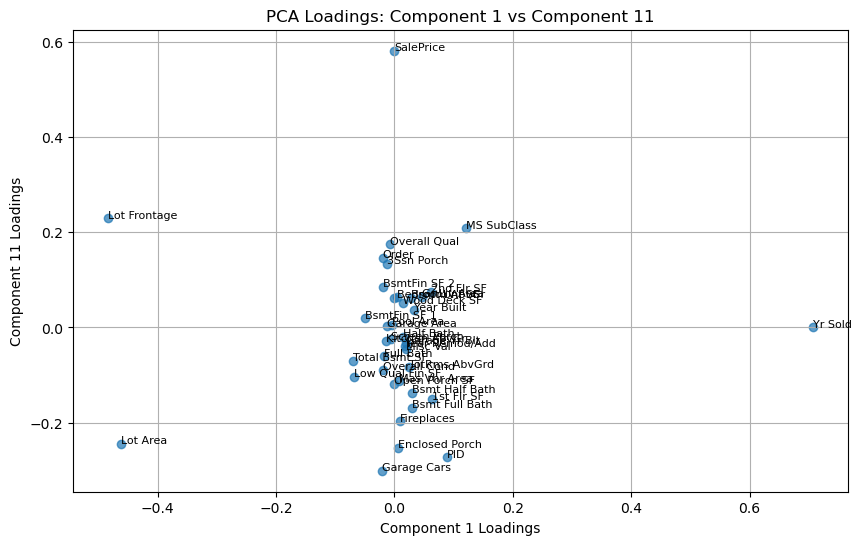

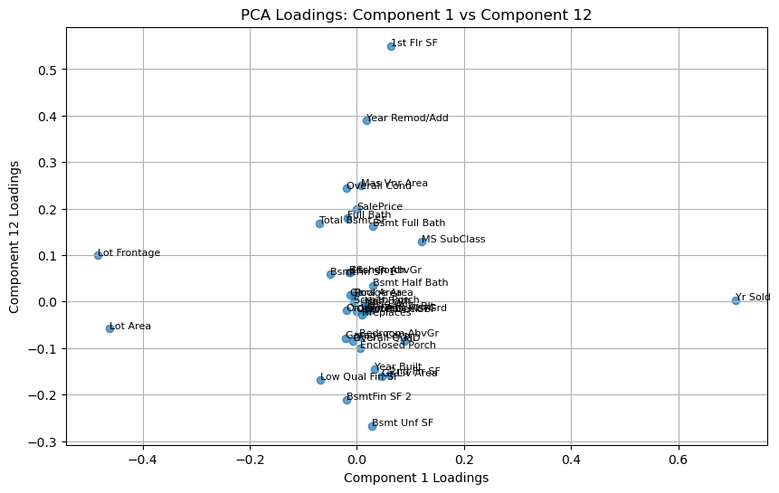

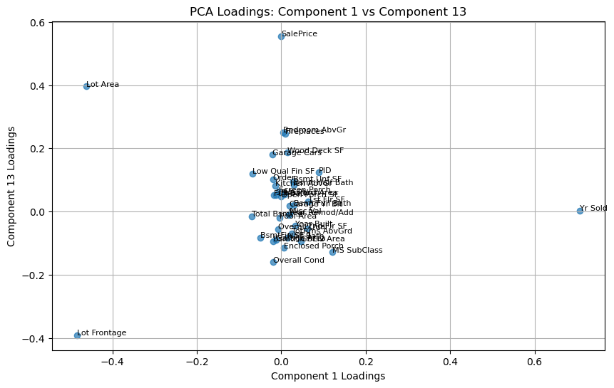

[7 more figures not shown]

```python
for i in range(1, num_components):
    plt.figure(figsize=(10, 6))
    plt.scatter(loadings.iloc[:, 0], loadings.iloc[:, i], alpha=0.7)
    plt.title(f'PCA Loadings: Component 1 vs Component {i+1}')
    plt.xlabel('Component 1 Loadings')
    plt.ylabel(f'Component {i+1} Loadings')
    for j, var_name in enumerate(numeric_data.columns):
        plt.annotate(var_name, (loadings.iloc[j, 0], loadings.iloc[j, i]), fontsize=8)
    plt.grid()
    plt.show()
```

#### 5 Perform the following:

##### A Show that Component loadings are orthogonal

```python
reduced_loadings = pca.components_[:20, :]
```

```python
orthogonal_check_reduced = np.dot(reduced_loadings, reduced_loadings.T)
print("Dot product of reduced loadings matrix:\n", orthogonal_check_reduced)
```

[output not shown]

[output cut: 46 more lines]

[output not shown]

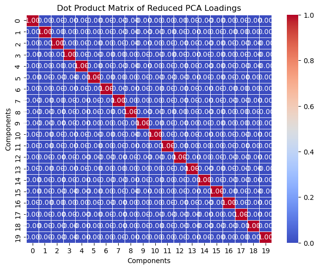

```python
plt.figure(figsize=(8, 6))
sns.heatmap(orthogonal_check_reduced, annot=True, cmap="coolwarm", fmt=".2f", linewidths=0.5)
plt.title("Dot Product Matrix of Reduced PCA Loadings")
plt.xlabel("Components")
plt.ylabel("Components")
plt.show()
```

The off-diagonal elements are close to zero, which therefore prove the orthogonality of the component loadings

##### B Show that Component scores are orthogonal.

```python
component_score_cov = np.cov(train_pca.T)
```

```python
print("Covariance Matrix of PCA Component Scores:\n", component_score_cov)
```

```
Covariance Matrix of PCA Component Scores:
 [[ 8.55816243e+00  3.00304854e-15  8.67789418e-16 ...  1.25057197e-16
   4.85998574e-16 -2.00436641e-16]
 [ 3.00304854e-15  3.26112067e+00 -5.94772310e-16 ... -8.20395464e-16
  -5.73756209e-17 -3.16677655e-16]
 [ 8.67789418e-16 -5.94772310e-16  2.67292352e+00 ... -1.49356418e-16
  -1.54343129e-16  1.82774966e-16]
 ...
 [ 1.25057197e-16 -8.20395464e-16 -1.49356418e-16 ...  6.05472985e-03
  -8.52540353e-17 -3.15388138e-19]
 [ 4.85998574e-16 -5.73756209e-17 -1.54343129e-16 ... -8.52540353e-17
   2.73008349e-30  1.90494398e-31]
 [-2.00436641e-16 -3.16677655e-16  1.82774966e-16 ... -3.15388138e-19
   1.90494398e-31  3.41588490e-30]]
```

```python
identity_check = np.allclose(component_score_cov, np.diag(np.diag(component_score_cov)), atol=1e-10)
print(f"Are PCA component scores orthogonal? {identity_check}")
```

```
Are PCA component scores orthogonal? True
```

[figure not shown]

```python
plt.figure(figsize=(10, 8))
sns.heatmap(component_score_cov, annot=True, cmap="coolwarm", fmt=".2f", linewidths=0.5)
plt.title("Covariance Matrix of PCA Component Scores")
plt.xlabel("Components")
plt.ylabel("Components")
plt.show()
```

The off-diagonal elements are close to zero, which therefore prove the orthogonality of the component scores

##### C Perform Test validation of Principal Components solution

```python
reduced_test_scores = pca.transform(test_data)[:, :20]
```

```python
reconstructed_test_data_reduced = np.dot(reduced_test_scores, reduced_loadings)
```

```python
reconstructed_test_data_reduced
```

```
array([[ 8.44757246e+07,  6.73389727e+08, -4.89177709e+07, ...,
        -9.52836534e+07,  3.66864561e+07, -1.66157924e+07],
       [ 4.94484097e+07,  3.94164355e+08, -2.86369771e+07, ...,
        -5.57750829e+07,  2.14724216e+07, -9.70206846e+06],
       [ 4.94593402e+07,  3.94254609e+08, -2.86438643e+07, ...,
        -5.57876190e+07,  2.14778241e+07, -9.70704852e+06],
       ...,
       [ 4.93717222e+07,  3.93556418e+08, -2.85936812e+07, ...,
        -5.56887207e+07,  2.14398660e+07, -9.69056971e+06],
       [ 4.94680713e+07,  3.94321171e+08, -2.86501967e+07, ...,
        -5.57976359e+07,  2.14807629e+07, -9.69748953e+06],
       [ 8.44636523e+07,  6.73300714e+08, -4.89111723e+07, ...,
        -9.52707372e+07,  3.66826820e+07, -1.66185812e+07]])
```

Based on these pairwise plots, the component Year Sold appears to not be interpretable as well, as it appears as a right-skewed anomaly. By removing the Month Sold component this comes into prominence, but we retain this component as it is indicative of date-time marking at the time of purchase and gives insight into the state of the economy.

```python
r2_selected = cumulative_variance_ratio[num_components - 1]
```

```python
print(f"R^2 (Proportion of variance explained by {num_components} components): {r2_selected:.4f}")
```

[output not shown]